# Майнор "Интеллектуальный анализ данных"

# Курс "Прикладные задачи анализа данных"

## Лабораторная работа №2. RecSys

В рамках данной лабораторной работы вам предлагается решить задачу рекомендательной системы на основе следующих данных:

- **rating.csv** - рейтинги аниме по 10 бальной шкале
- **anime.csv** - описание items

Скачать данные можно [здесь](https://drive.google.com/drive/u/1/folders/1FarHUuqQq4tQSlERB9K8uEfZAZT9tQWv)

# Данные

Данные содержат информацию об предподчтениях 73,516 пользователей в 12,294 аниме. Каждый пользователь может добавить аниме и выставить рейтниг.

Anime.csv

- anime_id - идентификатор аниме (items)
- name - полное название аниме
- genre - категория/категории для аниме (разделены запятой).
- type - тип: movie, TV, OVA, etc.
- episodes - количество эпизодов (для экранизаций)
- rating - средний рейтинг по аниме.
- members - количество членов коммьюнити к аниме

Rating.csv

- user_id - идентификатор пользователя (users)
- anime_id - идентификатор аниме
- rating - рейтинг пользователя по аниме (-1 пользователь смотрел, но не оставил рейтинг).

### `Если вычеслительные ресурсы не позволяют решить задачу на всех данных, то необходимо это сделать на "сэмпле" данных (выбрав от 5% ids' для user и item). Этот же подход справедлив и для оценки работы алгоритомв`

## Необходимо сделать:

```python
import pandas as pd
import numpy  as np
import seaborn as sns
import random
import matplotlib.pyplot as plt
```

```python
def draw(data):
    sns_plot = sns.distplot(data, color="blue")
    fig = sns_plot.get_figure()
```

```python
rating = pd.read_csv("rating.csv")
anime = pd.read_csv("anime.csv")
```

```python
print(f"Anime Data size: {len(anime)}")
print(f"Rating Data size: {len(rating)}")
```

```
Anime Data size: 12294
Rating Data size: 7813737
```

```python
print(f'User Id Unique {len(rating.user_id.unique())}')
print(f'Anime Id Unique {len(rating.anime_id.unique())}')
```

```
User Id Unique 73515
Anime Id Unique 11200
```

### Попробуем взять 5 процентов для ускорения наших действий

```python
short_user_ids = rating['user_id'].sample(int(len(rating.user_id.unique()) * 0.05))
short_anime_ids = rating['anime_id'].sample(int(len(rating.anime_id.unique()) * 0.05))
len(short_anime_ids)
```

```
560
```

```python
rating = rating[(rating['user_id'].isin(short_user_ids)) & (rating['anime_id'].isin(short_anime_ids))]
len(rating)
```

```
264260
```

```python
print(len(rating.user_id.unique()))
print(len(rating.anime_id.unique()))
```

```
3451
464
```

Безрейтинговые выбранные пользователи и аниме не вошли в нашу выборку

### Задание №1 : Exploratory analysis (2 балла):

- Распределение числа пользователей по количеству взаимодействий
- Разпределение числа "айтемов" по количеству взаимодействий
- Распределение числа рейтингов, средних рейтингов по пользователям, по "айтемам"
- и т.д. (бонус)

### Распределение числа пользователей по количеству взаимодействий

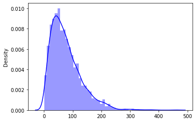

```python
draw_data = rating.user_id.value_counts().values
draw(draw_data)
```

### Разпределение числа "айтемов" по количеству взаимодействий

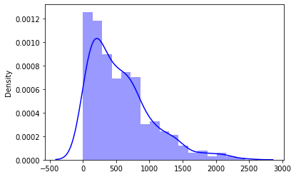

```python
draw_data = rating.anime_id.value_counts().values
draw(draw_data)
```

### Распределение числа рейтингов, средних рейтингов по пользователям, по "айтемам"

#### Число рейтингов по юзерам

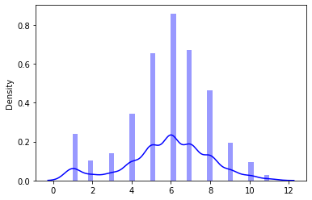

```python
draw_data = rating.groupby('user_id').rating.nunique().values
draw(draw_data)
```

#### Число рейтингов по айтемам

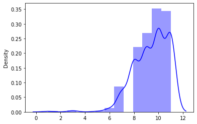

```python
draw_data = rating.groupby('anime_id').rating.nunique().values
draw(draw_data)
```

#### Средний рейтинг аниме

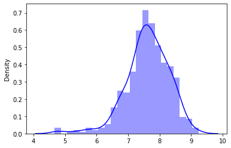

```python
draw_data = rating[rating.rating != -1].groupby('anime_id').rating.mean().values
draw(draw_data)
```

### Задание №2 : Оценить разреженность данных по рейтингу (1/2 балла)

```python
users_id_index = { id: index for index, id in enumerate(rating.user_id.unique()) }
anime_id_index = { id: index for index, id in enumerate(rating.anime_id.unique())}
matrix = np.zeros((rating.user_id.unique().size, rating.anime_id.unique().size))
for ind, iterr in rating.iterrows():
    matrix[users_id_index[iterr.user_id], anime_id_index[iterr.anime_id]] = iterr.rating
matrix.shape
```

```
(3451, 464)
```

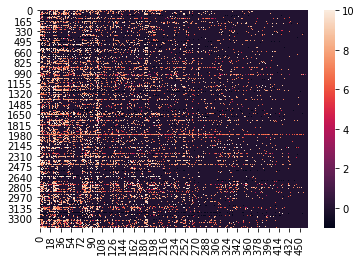

```python
sns.heatmap(matrix)
```

### Оценим разреженность

```python
denom = rating.user_id.unique().size * rating.anime_id.unique().size
print(f'Sparsity {(1.0 - ((np.count_nonzero(matrix) * 1.0) / denom)) * 100} %')
```

```
Sparsity 83.49678753784511 %
```

### Задание №3 : Разделить данные на тренировочные и валидационные (1/2 балла)

```python
matrix_train = matrix.copy()
test_val = []
for user_i in range(matrix_train.shape[0]):
    test_sample = (matrix_train[user_i] > 7).nonzero()[0]
    test_val.append(random.sample(list(test_sample), k=(5 if 5 <= len(test_sample) else len(test_sample))))
    for anime_i in test_sample:
        matrix_train[user_i][anime_i] = 0
test_val
```

[output not shown]

[output cut: 986 more lines]

### Задание №4 : Решить задачу на основе предложения всем юзерам наиболее популярных item (1 балл)

```python
popul = np.count_nonzero(matrix_train, axis=0)
rat = sorted(range(len(popul)), key=lambda k: popul[k])
rec_popular = [rating.anime_id.unique()[i] for i in rat]
print(rec_popular[:10])
print(rat[:10])
```

```
[6975, 28339, 4614, 1885, 4387, 5496, 1402, 506, 930, 2050]
[439, 462, 463, 438, 458, 420, 460, 461, 450, 453]
```

### Задание №5 : Решить задачу на основе коллоборативной фильтрации (2 балла)

- Реализовать один из методов коллоборативной фильтрации SVD, SVD++, ALS, ALS with implicit feedback

### SVD

```python
def argmax(a, k):
    return np.argpartition(a, -k)[-k:]
```

```python
from numpy.linalg import svd

p = 32
u, d, v = svd(matrix)
U = u[:, :p]
D = np.diag(d)[:p, :p]
V = v[:p, :]
svd_pred = U @ D @ V
```

```python
result = argmax(svd_pred[0], 5)
result
```

```
array([337, 164, 200, 112, 203], dtype=int64)
```

```python
anime.iloc[result]
```

|  | anime_id | name | genre | type | episodes | rating | members |
| --- | --- | --- | --- | --- | --- | --- | --- |
| 337 | 1530 | Kanon (2006) | Drama, Romance, Slice of Life, Supernatural | TV | 24 | 8.17 | 163171 |
| 164 | 853 | Ouran Koukou Host Club | Comedy, Harem, Romance, School, Shoujo | TV | 26 | 8.39 | 422271 |
| 200 | 121 | Fullmetal Alchemist | Action, Adventure, Comedy, Drama, Fantasy, Mag... | TV | 51 | 8.33 | 600384 |
| 112 | 136 | Hunter x Hunter | Action, Adventure, Shounen, Super Power | TV | 62 | 8.48 | 166255 |
| 203 | 6675 | Redline | Action, Cars, Sci-Fi, Sports | Movie | 1 | 8.33 | 109392 |

```python
anime.iloc[result].describe()
```

|  | anime_id | rating | members |
| --- | --- | --- | --- |
| count | 5.000000 | 5.000000 | 5.00000 |
| mean | 1863.000000 | 8.340000 | 292294.60000 |
| std | 2752.427383 | 0.113137 | 210846.62013 |
| min | 121.000000 | 8.170000 | 109392.00000 |
| 25% | 136.000000 | 8.330000 | 163171.00000 |
| 50% | 853.000000 | 8.330000 | 166255.00000 |
| 75% | 1530.000000 | 8.390000 | 422271.00000 |
| max | 6675.000000 | 8.480000 | 600384.00000 |

### Задание №6 Решить задачу на основе контент-based подхода, выбрав один из методов решения (2 балла):

- На основание векторов с факторизационной матрицы
- При помощи "ембеддингов" item'ов

#### Для наиболее понравишегося аниме найдем похожие на основании векторов с факторизационной матрицы

```python
recs = []
for user_i in range(matrix_train.shape[0]):
    best_index = np.where(matrix_train[user_i] == matrix_train[user_i].max())[0][0]
    recs.append(((V.T - V.T[best_index])**2).mean(axis=1).argsort()[1:1 + 5])
based_by_cont = np.array(recs)
based_by_cont
```

```
array([[134, 128,  29, 158, 358],
       [240, 312, 180, 144, 231],
       [362, 323, 321, 125, 334],
       ...,
       [ 78, 147,  88, 410, 369],
       [206, 268,   5, 107, 407],
       [411,  95, 396, 284, 308]], dtype=int64)
```

### Задание №7 Оценить работу алгоритмов выбрав одну из метрик, сделать вывод по результатам работы (2 балла):

### MAP@k

```python
def ap(actual, pred):
        score = 0.0
        hits = 0.0
        for i,p in enumerate(pred):
            if p in actual:
                hits += 1.0
                score += hits / (i+1.0)
        if hits != 0:
            return score / hits
        return 0

def mapka(actual, pred):
    scores = []
    for a,p in zip(actual, pred):
        if len(a) >= len(p):
            scores.append(ap(a, p))
        continue
    return np.mean(scores)
```

## Content

```python
mapka(test_val, based_by_cont)
```

```
0.05547789336801039
```

## Popular

```python
mapka(test_val, np.stack([rat[:5]] * len(test_val)))
```

```
0.00024382314694408323
```

## SVD

```python
mapka(tes_val, result)
```

[output not shown]

`Бонус (1 балл) - дополнительные графики и характеристики в EDA и правильно сделанные выводы`

# `Дедлайн - 08 июня 23:59`